# scientific_notes

Running head:  
Scientific Notes

**First report of *Phyllocoptes fructiphilus* in Florida**

Austin **Fife**<sup>1</sup>*, Sam **Bolton**<sup>2</sup>, Mathews **Paret**<sup>3</sup>, and Xavier **Martini**<sup>4</sup>

<sup>1</sup> University of Florida, Department of Entomology and Nematology, Gainesville, Florida, 32611, USA, E-mail: afife@ufl.edu

<sup>2</sup> The Florida Department of Agriculture and Consumer Services, Division of Plant Industry, Gainesville, Florida, 32614, USA, E-mail: Samuel.Bolton@FDACS.gov

<sup>3</sup> University of Florida, Department of Entomology and Nematology, Gainesville, Florida, 32611, USA, E-mail: paret@ufl.edu

<sup>4</sup> University of Florida, Department of Entomology and Nematology, Gainesville, Florida, 32611, USA, E-mail: xmartini@ufl.edu

*Corresponding author; E-mail: xmartini@ufl.edu

*Phyllocoptes fructiphilus* Keifer (Acari: Eriophyidae is a microscopic eriophyid mite. Eriophyid mites are very host specific (Oldfield 1996, Skoracka et al. 2009) and *P. fructiphilus* feeds only on plants in the genus *Rosa* (Amrine Jr 1996). *Phyllocoptes fructiphilus* is associated with the rose rosette emaravirus (rose rosette virus) and acts as the only known vector of rose rosette virus. Infection is associated commonly with the following symptoms: witches’ brooms, rosetting, deformed flowers, increased thorn density, elongated shoots, reddened leaves and stems, and increased die-back that ultimately kills the rose host (Amrine Jr 1996). This disease is known as Rose Rosette Disease (RRD). and is the most serious disease of roses, creating millions of dollars of losses for growers. Rose Rosette Disease and the mite have invaded the southeastern united states as they followed the range expansion of the non-native *Rosa multiflora* (Thunb) towards the coast (Amrine Jr 2002, Otero-Colina et al. 2018).

RRD has been detected in Florida in 2014 on 15 plants; however, the plants were destroyed and *P. fructiphilus* were not detected on the roses at that time (Babu et al. 2014).

In 2018 we began a series of surveys along the borders of northern Florida and southern Georgia. Survey efforts initially focused on cities with populations over 1,000, including Leon, Gadsden and other counties in the surrounding regions. Rose tissue samples were taken from the periphery of various roses: samples included a mixture of flowers, fruits, buds and short lengths of rose cane, trimmed with bypass pruners and stored in quart sized plastic baggies. Pruners were sanitized with 70% ethanol between cuts. Rose species and coordinates were recorded to map out sites which had predatory mites, *P. fructiphilus*, or possibly RRD.

Samples were processed using a washing method derived from Monfreda et al. (2007): cut roses were soaked in a 500 mL beaker with a solution of 1:1 bleach:water with few drops of dishwasher detergent. The solution was stirred vigorously with a glass rod to dislodge any mites. This solution was then poured over a stack of sieves with decreasing screen sizes: 180 μm, 53 μm and 25 μm. The beaker and rose pieces were further rinsed with tap water over the sieve stack to knock off any remaining mites. The 25 μm sieve screen traps mites which are the size of *P. fructiphilus*. This sieve was then backwashed from the underside of the screen with a water-filled wash bottle, starting from the highest point of the sieve and working to the bottom of the sieve to flush the trapped debris into a 50 ml centrifuge tube for storage and future observation. Samples were observed under a dissecting microscope. Mites found among the plant debris were siphoned off with a glass pipette and subsequently stored in micro-centrifuge containers filled with 95% ethanol as a preservative. Select specimens were mounted directly into Hoyer’s slide mountant (Hempstead Halide, Inc. Galveston, TX), dried at 90°C, then ringed with nail polish.

This is the first record for *P. fructiphilus* in Florida. More importantly, RRV is currently not established in Florida. None of the mite-infested roses had symptoms of RRD and none were positive for RRV. However, the presence of *P. fructiphilus*, along with past detections of RRV in Florida warrants increased monitoring for the mite and virus in Florida. There is a critical need to develop methods to manage *P. fructiphilus* and RRV, or the US rose industry stands to lose millions on mite control.

Summary

The invasive mite *Phyllocoptes fructiphilus* (Acari: Trombidiformes, Eriophyidae) feeds on plants in the genus *Rosa* and is known as the primary vector of Rose Rosette Virus, the causal agent of Rose Rosette Disease (RRD) (Bunyavirales: Emaraviridae). The mite *P. fructiphilus* is reported for the first time in Florida, USA. No roses showed signs or symptoms of viral infection, and no virus was detected using molecular methods. *P. fructiphilus* represents a potential threat to the Florida rose industry if RRD becomes established.

Resumen

El ácaro invasivo *Phyllocoptes fructiphilius* (Acari: Trombidiformes, Eriophyidae) se alimenta en plantas del género *Rosa* y es conocido principalmente como vector de la Virus Rosetón Rosal, el agente causal de la Enfermedad Rosetón Rosal (ERR) (Bunyavirales: Emaraviridae). El ácaro *P. fructiphilus* se reporta por la primera vez en Florida, USA. Ninguna rosa se mostró señales ni síntomas de infección viral, y ninguno virus fue detectado con métodos moleculares. *P. fructiphilus* se representa una amenaza potencial para la industria rosal Florideña si la ERR se establezca en Florida.

Key Words: Rose Rosette Disease; Rose Rosette Virus; Emaravirus

Acknowledgments: this research was supported by a grant awarded by the Florida Nursery, Growers and Landscape Association. We thank Jessie Griesheimer and James Brannin for assistance during the experiments.

[interactive chart not shown]

Figure 1: Presence of *Phyllocoptes fructiphilus* in Leon County, Florida in (A) Feburary 2019 and (B) July 2019. Orange dots indicate sites sampled which had *P. fructiphilus*. Gray areas indicate previously surveyed areas where no *P. fructiphilus* were found.

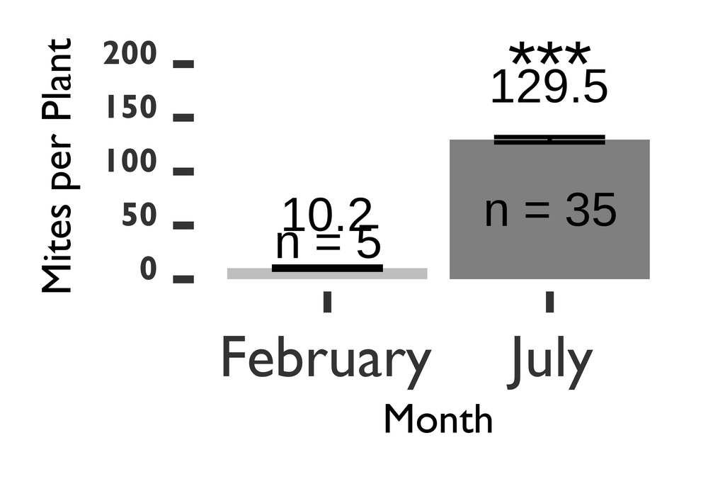

**References Cited**

**Amrine Jr, J. W.** **1996**. *Phyllocoptes fructiphilus* and biological control of multiflora rose, pp. 741–749. *In* Helle, W., Lundquist, E.E., Sabelis, M.W., Bruin, J. (eds.), Eriophyoid Mites. Their Biology, Natural Enemies, and Control, World Crop Pests. Elsevier.

**Amrine Jr, J. W.** **2002**. *Rosa multiflora*. Biological control of invasive plants in the Eastern United States. 265–292.

**Babu, B., H. Dankers, E. Newberry, C. Baker, T. Schubert, G. Knox, and M. Paret**. **2014**. First report of rose rosette virus associated with rose rosette disease infecting knockout roses in Florida. Plant Disease. 98: 1449–1449.

**Babu, B., A. Jeyaprakash, D. Jones, T. S. Schubert, C. Baker, B. K. Washburn, S. H. Miller, K. Poduch, G. W. Knox, F. M. Ochoa-Corona, and M. L. Paret**. **2016**. Development of a rapid, sensitive TaqMan real-time RT-PCR assay for the detection of rose rosette virus using multiple gene targets. Journal of Virological Methods. 235: 41–50.

**Babu, B., B. K. Washburn, T. S. Ertek, S. H. Miller, C. B. Riddle, G. W. Knox, F. M. Ochoa-Corona, J. Olson, Y. Z. Katırcıoğlu, and M. L. Paret**. **2017**. A field based detection method for rose rosette virus using isothermal probe-based reverse transcription-recombinase polymerase amplification assay. Journal of Virological Methods. 247: 81–90.

**Monfreda, R., G. Nuzzaci, and E. De Lillo**. **2007**. Detection, extraction, and collection of eriophyoid mites. Zootaxa. 1662: 35–43.

**Oldfield, G. N.** **1996**. Diversity and host plant specificity. *In* Helle, W., Lundquist, E.E., Sabelis, M.W., Bruin, J. (eds.), Eriophyoid Mites. Their Biology, Natural Enemies, and Control, World Crop Pests. Elsevier.

**Otero-Colina, G., R. Ochoa, J. W. Amrine Jr, J. Hammond, R. Jordan, and G. R. Bauchan**. **2018**. Eriophyoid mites found on healthy and rose rosette diseased roses in the United States. Journal of Environmental Horticulture. 36: 146–153.

**Skoracka, A., L. Smith, G. Oldfield, M. Cristofaro, and J. W. Amrine**. **2009**. Host-plant specificity and specialization in eriophyoid mites and their importance for the use of eriophyoid mites as biocontrol agents of weeds. Experimental and Applied Acarology. 51: 93–113.